# Parentage and Phenotype Analysis

## Phenotype analysis: how heritable is body size?

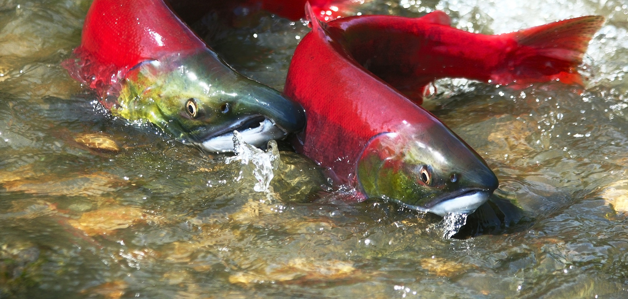

Photo credit: Eniday.com<sup>1</sup>https://www.eniday.com/en/education_en/climate-change-sockeye-salmon/

## First let's load the libraries we'll need

```r
library(dplyr)
library(tidyr)
library(knitr)
library(ggplot2)
```

**Note:** to hide the output of these commands, add `message=FALSE` to the curvy brackets with `{r}`. Press the "run current chunk" button, *not* Ctrl-Enter. It gave me some random errors when I just pressed ctrl-enter.

## Loading the data frame

```r
parentage_data <- read.csv("../data_8-10/parentage_with_phenotypes_CSV.csv")
```

This is a data frame of various data on a sockeye salmon population (parentage, phenotypes, location seen in their home creek, days they were seen, etc.)

## Next, we'll manipulate the data.

- we can use `library(tidyr)` to organize messy columns in the data frame.
- For example, look at the `locations` column in `parentage_data`:

| parentage_data$locations[1:4] |
| --- |
| a,a |
| a |
| a |
| a,a mouth,a,a,a,a |

## What are we looking at?

These are locations within two creeks (A creek and C creek) at which different fish (represented in each row) were seen. Obviously, there are multiple data in single cells.

| parentage_data$locations[1:4] |
| --- |
| a,a |
| a |
| a |
| a,a mouth,a,a,a,a |

## How the heck do we tidy this data?!

## filter the data frame

```r
tidy_data <- parentage_data %>%
  select(OFFSPRING_ID, locations)
separate_rows(tidy_data, locations, sep = ",") %>%
  group_by(OFFSPRING_ID, locations) %>%
  mutate(count = n()) %>%
  distinct() %>%
  spread(locations, count)
```

```
## # A tibble: 668 x 7
## # Groups:   OFFSPRING_ID [668]
##    OFFSPRING_ID     a `a beach` `a mouth`     c `c beach` `c mouth`
##           <int> <int>     <int>     <int> <int>     <int>     <int>
##  1         7715     2        NA        NA    NA        NA        NA
##  2         7716     1        NA        NA    NA        NA        NA
##  3         7717     1        NA        NA    NA        NA        NA
##  4         7718     5        NA         1    NA        NA        NA
##  5         7719     2        NA        NA    NA        NA        NA
##  6         7720     3        NA        NA    NA        NA        NA
##  7         7721     2        NA         1    NA        NA        NA
##  8         7722     5        NA        NA    NA        NA        NA
##  9         7723     2        NA        NA    NA        NA        NA
## 10         7724     2        NA         2    NA        NA        NA
## # ... with 658 more rows
```

## Hooray!

Now each variable has its own column, and observations are reported as the number of times a fish was seen at each location.

## Now to filter the data for our use today

```r
#Filtering out NAs and blanks by selecting sex columns only with m or f
filtered_parentage_data <- parentage_data %>%
  select(sex, length, depth, sex.1, length.1, depth.1, sex.2, length.2, depth.2) %>%
  filter(sex == "m" | sex== "f") %>%
  filter(sex.1 == "m" | sex.1 =="f") %>%
  filter(sex.2 =="m" | sex.2 == "f") %>%

#Creating length:depth ratio columns for offspring and each parent
  mutate(LD_ratio = length/depth) %>%
  mutate(LD.1_ratio = length.1/depth.1) %>%
  mutate(LD.2_ratio = length.2/depth.2) %>%
  na.omit() #ensuring all NAs are removed
```

*Notice a pipe was used for this entire chunk*

## Let's see what we've done so far:

| sex | length | depth | sex.1 | length.1 | depth.1 | sex.2 | length.2 | depth.2 | LD_ratio | LD.1_ratio | LD.2_ratio |
| --- | --- | --- | --- | --- | --- | --- | --- | --- | --- | --- | --- |
| f | 388 | 90 | m | 400 | 116 | f | 428 | 111 | 4.311111 | 3.448276 | 3.855856 |
| f | 398 | 99 | m | 400 | 116 | f | 428 | 111 | 4.020202 | 3.448276 | 3.855856 |
| f | 425 | 94 | m | 462 | 157 | f | 447 | 114 | 4.521277 | 2.942675 | 3.921053 |
| m | 395 | 109 | m | 400 | 103 | f | 387 | 111 | 3.623853 | 3.883495 | 3.486486 |
| m | 415 | 128 | m | 431 | 124 | f | 410 | 91 | 3.242188 | 3.475807 | 4.505495 |

## Next we'll be calculating the **z-scores** of the parents and offspring.

A z-score is the distance of a value from the mean in terms of standard deviations. Statistically, values with z-scores greater than 2 (more than 2 standard deviations from the mean) are considered unusual.

## But first…

Before we can calculate z-scores, we need the mean and standard deviation of the length:depth columns.

```r
#standard deviations
sd_dad <- sd(filtered_parentage_data$LD.1_ratio)
sd_mom <- sd(filtered_parentage_data$LD.2_ratio)
sd_offspring <- sd(filtered_parentage_data$LD_ratio)

  #means
mean_dad <- mean(filtered_parentage_data$LD.1_ratio)
mean_mom <- mean(filtered_parentage_data$LD.2_ratio)
mean_offspring <- mean(filtered_parentage_data$LD_ratio)
```

## Now for the z-scores, featuring a fancy for loop

## Dad z-scores

```r
for (i in seq(1, length(filtered_parentage_data$LD.1_ratio))) {
  #establishing the data to which the loop will apply (the dad length:depth (LD.1) ratio column)
  z_score_dad <- (filtered_parentage_data$LD.1_ratio[i] - mean_dad)/ sd_dad
  #i is used as a generic variable. We're subtracting each entry in LD.1_ratio from the mean and dividing that difference by the standard deviation
  filtered_parentage_data$z_score_dad[i] <- as.numeric(z_score_dad)
  #assigning the results of the above line to the column "z_score_dad"
}
    #double check that it worked properly...
head(filtered_parentage_data$z_score_dad)
```

```
## [1] -0.08279160 -0.08279160 -2.49565180  1.99418987  0.04859165 -1.49056754
```

```r
#(filtered_parentage_data$LD.1_ratio[1] - mean_dad)/sd_dad
# If the loop worked correctly, this should yield the same value as the first output value from the loop
```

## Mom z-scores

```r
for (i in seq(1, length(filtered_parentage_data$LD.2_ratio))) {
  z_score_mom <- (filtered_parentage_data$LD.2_ratio[i] - mean_mom)/ sd_mom
  filtered_parentage_data$z_score_mom[i] <- as.numeric(z_score_mom)

}
head(filtered_parentage_data$z_score_mom)
```

```
## [1] -0.37144982 -0.37144982 -0.09387941 -1.94401240  2.39433833  0.80128901
```

## Offspring z-scores

```r
for (i in seq(1, length(filtered_parentage_data$LD_ratio))) {
  z_score_offspring <- (filtered_parentage_data$LD_ratio[i] - mean_offspring)/ sd_offspring
  filtered_parentage_data$z_score_offspring[i] <- as.numeric(z_score_offspring)

}
head(filtered_parentage_data$z_score_offspring)
```

```
## [1]  0.28482151  0.12709609  0.39876926 -0.08779674 -0.29472868  0.12656950
```

##### *These all look like reasonable z-scores! That's encouraging.*

## Graphing z-scores

Now that we have the z-scores, let's graph them to see if there are any correlations between parents and offspring.

More specifically, We'll make scatter plots for mom z-score vs. ofspring z-score and dad z-score vs. offspring z-score.

## Z-score graphs: Mom vs. offspring

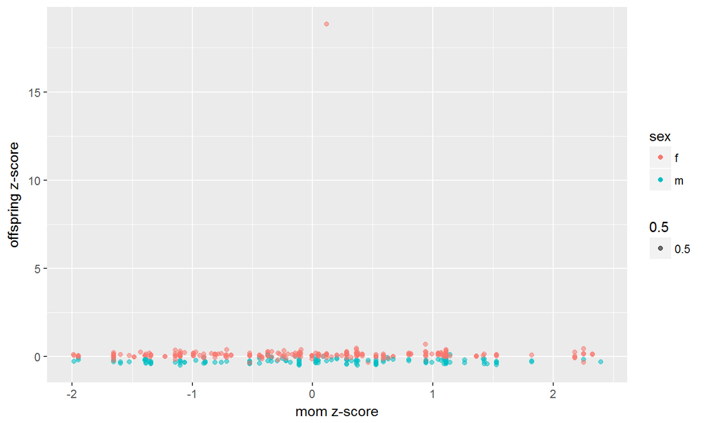

```r
ggplot(data = filtered_parentage_data) +
  geom_point(mapping = aes(x = filtered_parentage_data$z_score_mom, y = filtered_parentage_data$z_score_offspring, color = sex, alpha = 0.5))+
  labs(x = "mom z-score", y = "offspring z-score")
```

## Z-score graphs: Dad vs. offspring

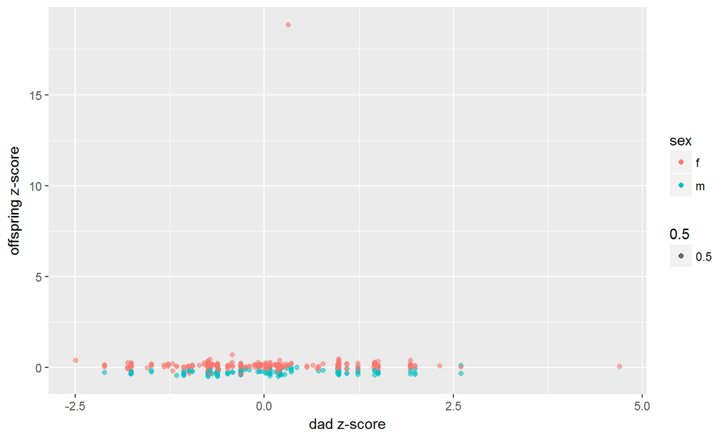

```r
ggplot(data = filtered_parentage_data) +
  geom_point(mapping = aes(x = filtered_parentage_data$z_score_dad, y = filtered_parentage_data$z_score_offspring, color = sex, alpha = 0.5))+
  labs(x = "dad z-score", y = "offspring z-score")
```

## How do they look?

We can see that there's one obvious outlier in both plots throwing off the scale and obscuring any trends that may be there. Let's fix that (and also take out that "0.5" legend that makes no sense)…

## Cleaned up graphs: Mom vs. offspring

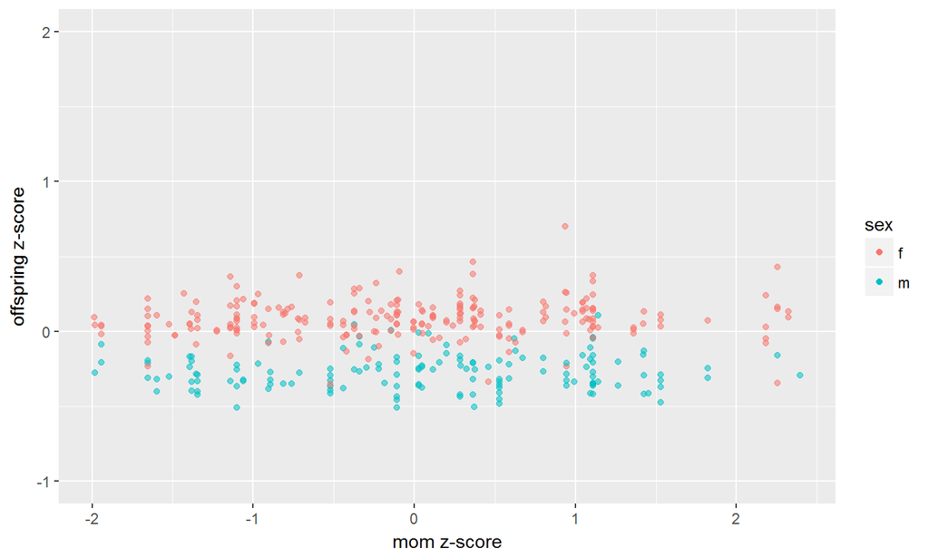

```r
  ggplot(data = filtered_parentage_data) +
  geom_point(mapping = aes(x = filtered_parentage_data$z_score_mom, y = filtered_parentage_data$z_score_offspring, color = sex, alpha = 0.5))+
  labs(x = "mom z-score", y = "offspring z-score") +
  ylim(-1, 2)+
  guides(alpha = FALSE)
```

## Cleaned up graphs: Dad vs. offspring

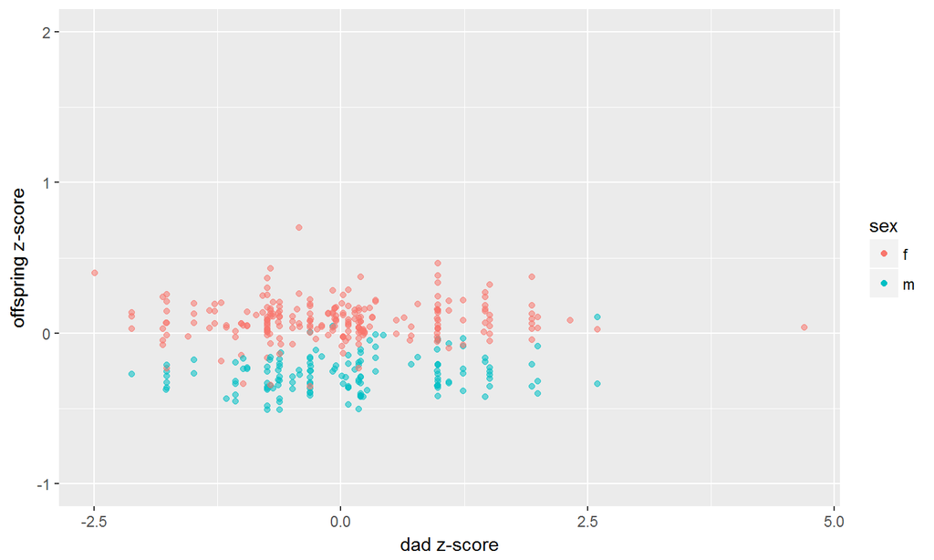

```r
  ggplot(data = filtered_parentage_data) +
    geom_point(mapping = aes(x = filtered_parentage_data$z_score_dad, y = filtered_parentage_data$z_score_offspring, color = sex, alpha = 0.5))+
    labs(x = "dad z-score", y = "offspring z-score")+
    ylim(-1,2)+
    guides(alpha = FALSE)
```

## That's better! From these graphs we can see:

- There appears to be no correlation between parent z-score (either mom or dad) and offspring z-score
- Most offspring z-scores are between -0.5 and 0.5
- Mst mom z-scores range from -2 to 2, and most dad z-scores range from -2.5 to 2.5
- Female offspring tend to have more positive z-score values, and male offspring tend to have more negative z-score values